# MAB Rpath MSE test

Sarah Gaichas

June 23, 2026

# Introduction

# Load the balanced Mid Atlantic Rpath model

This model is the same used in S. Weisberg et al in press, comparing all three NEUS Rpaths.

This model has had discards removed for the paper above so I’m only using it for testing. We will want to add them back in for any real analysis.

```r
load(here::here("outputs/MAB_params_Rpath_no_disc.RData"))
load(here::here("outputs/MAB_Rpath_no_disc.RData"))

MAB <- Rpath::rpath(MAB.rpath.params) # gives same object as MAB.rpath loaded above
```

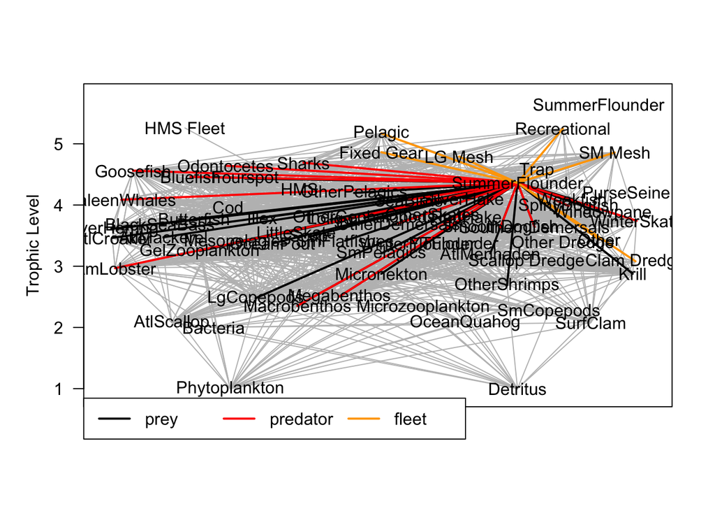

```r
#visualize a group
# the all-0 HMS Fleet breaks this plotting function
# add small HMS Fleet catch for HMS
hms_catch<-c(rep(0,14),0.003,rep(0,39),rep(NA,12))
MAB.rpath.params$model[,"HMS Fleet":=hms_catch]

MAB2 <- Rpath::rpath(MAB.rpath.params)

webplot(MAB2, labels=T, fleets=T, highlight = 'SummerFlounder') #fleets not working in MAB plot
```

# MAB Rpath fishing scenarios and simulated data

We will use the MAB for actual modeling. All of this code is modified from https://github.com/thefaylab/cinar-mse-projects/blob/main/multispecies/RpathOM_HCR_PSPS.Rmd

These are simulated fishing scenarios to create contrast in biomass and catch.

```r
#Add variable fishing in a dynamic run
MAB.scene <- rsim.scenario(MAB, MAB.rpath.params, years = 1983:2022)

MAB.scene <- adjust.fishing(MAB.scene, parameter = 'ForcedEffort', group = 'LG Mesh',
                            sim.year = 1983:2017, value = c(rep(0, 15), rep(2.5, 5),
                                                            rep(5, 5), rep(10, 5),
                                                            rep(2.5, 5)))
MAB.scene <- adjust.fishing(MAB.scene, parameter = 'ForcedEffort', group = 'Fixed Gear',
                           sim.year = 1983:2017, value = c(rep(0, 15), rep(2.5, 5),
                                                           rep(5, 5), rep(10, 5),
                                                           rep(2.5, 5)))
MAB.scene <- adjust.fishing(MAB.scene, parameter = 'ForcedEffort', group = 'SM Mesh',
                            sim.year = 1983:2017, value = c(rep(0, 15), rep(1, 5),
                                                            rep(1.5, 5), rep(2, 5),
                                                            rep(0.5, 5)))
MAB.scene <- adjust.fishing(MAB.scene, parameter = 'ForcedEffort', group = 'Recreational',
                            sim.year = 1983:2017, value = c(rep(0, 15), rep(1, 5),
                                                            rep(1.5, 5), rep(2, 5),
                                                            rep(0.5, 5)))


MAB.run <- rsim.run(MAB.scene, years = 1983:2022)
```

This is the impact of the fishing scenarios we have implemented across many of the MAFMC managed stocks. Butterfish and squids are seeing some predatory release despite an increase in fishing effort. We havent done anything with dredge gear so surfclams and quahogs are unaffected.

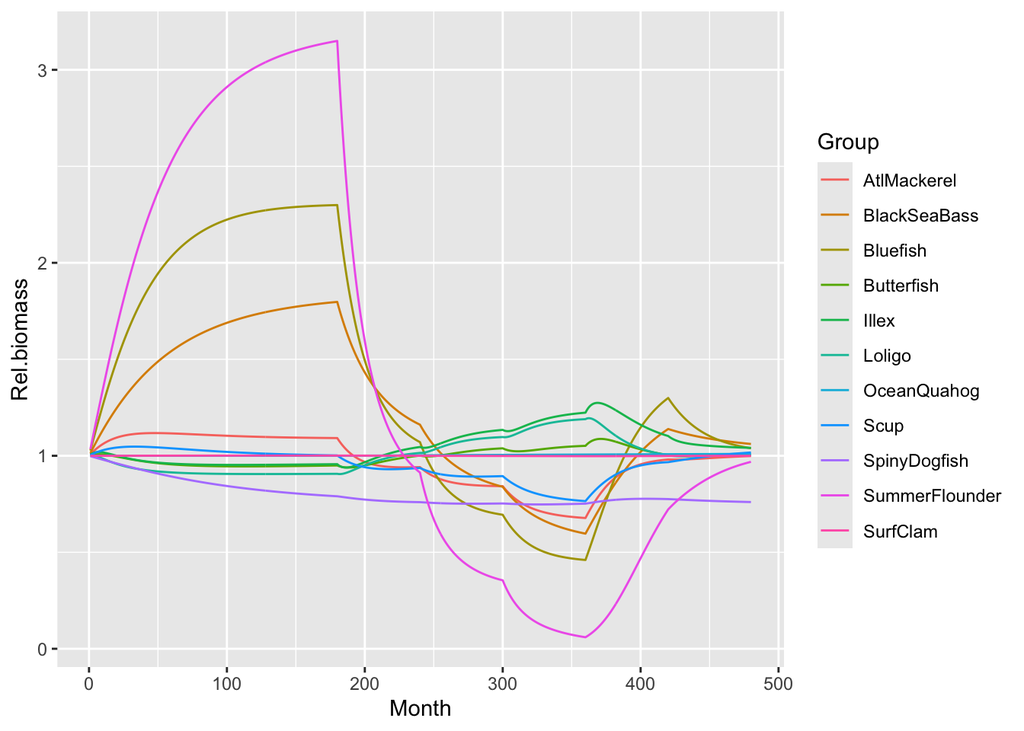

```r
#Plot results
MAB.bio <- as.data.table(MAB.run$out_Biomass)
MAB.bio[, Month := 1:nrow(MAB.bio)]
MAB.bio <- data.table::melt(MAB.bio, id.vars = 'Month', variable.name = 'Group',
                           value.name = 'Biomass')
start <- data.table::as.data.table(MAB.run$start_state$Biomass)
start[, Group := names(MAB.run$start_state$Biomass)]

MAB.bio <- merge(MAB.bio, start, by = 'Group')
MAB.bio[, Rel.biomass := Biomass / V1]

ggplot2::ggplot(MAB.bio[Group %in% c('SummerFlounder', 'Scup', 'Butterfish', 'SpinyDogfish',
                                     'BlackSeaBass', 'Bluefish', 'AtlMackerel', 'Loligo',
                                     'Illex', 'SurfClam', 'OceanQuahog')],
                ggplot2::aes(x = Month, y = Rel.biomass, col = Group)) +
  ggplot2::geom_line()
```

This function generates biomass and catch data from the system with both observation error and bias (if we want) No bias added here.

```r
#Need a function to pull observed data from the system:

GenData <- function(Rsim.output, group, sim.year, Sigma = 0.3, bias = 1, freq = 1){
  # This routine generates data (unbiased generally) for the biological groups
  #and returns the appropriate object

  node     <- extract.node(Rsim.output, group)
  TrueBio  <- node$AnnualBiomass[which(names(node$AnnualBiomass) == sim.year)]
  Observed <- c()
  for(Iyear in seq_along(sim.year)){
    if (Iyear %% freq == 0){
      Observed[Iyear] <- TrueBio[Iyear] * exp(rnorm(1, 0, Sigma) - Sigma^2/2)
    } else Observed[Iyear] <- -1
  }
  Catch <- as.numeric(node$AnnualTotalCatch[which(names(node$AnnualBiomass) == sim.year)])

  out <- list(ObsBio = Observed, TotCatch = Catch, Fmort = Catch / Observed)

  return(out)
}
```

These are the generated “datasets” for summer flounder, scup, butterfish, and Illex. This group is just an example, we can add or subtract stocks as we wish.

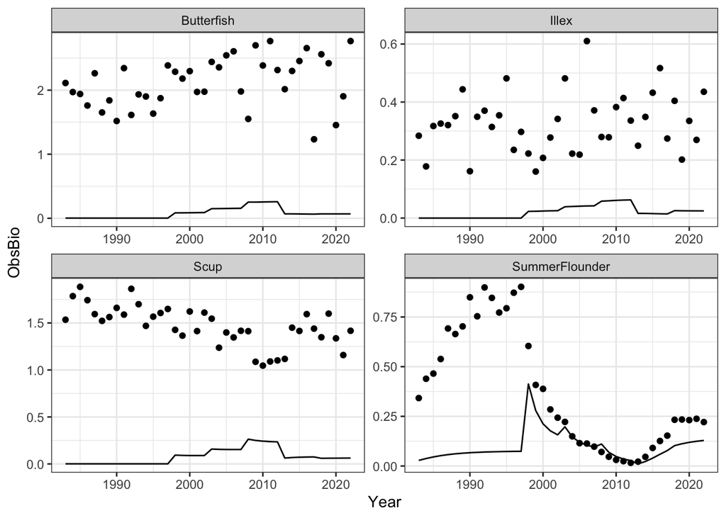

```r
#Now generate the initial data set and fit to a Schaefer production model

setkey(123)
sf <- GenData(MAB.run, 'SummerFlounder', 1983:2022, Sigma = 0.1)
scup <- GenData(MAB.run, 'Scup', 1983:2022, Sigma = 0.1)
butter <- GenData(MAB.run, 'Butterfish', 1983:2022, Sigma = 0.2)
illex <- GenData(MAB.run, 'Illex', 1983:2022, Sigma = 0.3)

#Merge into 1 file
MAB.data <- data.table(Year = 1983:2022,
                      Species = c(rep('SummerFlounder', 40), rep('Scup', 40),
                                  rep('Butterfish', 40), rep('Illex', 40)),
                      ObsBio = c(sf$ObsBio, scup$ObsBio, butter$ObsBio, illex$ObsBio),
                      TotCatch = c(sf$TotCatch, scup$TotCatch, butter$TotCatch, illex$TotCatch),
                      Fmort = c(sf$Fmort, scup$Fmort, butter$Fmort, illex$Fmort))

#plot
MAB.data |>
  ggplot2::ggplot()+
  ggplot2::geom_point(ggplot2::aes(x=Year, y=ObsBio)) +
  ggplot2::geom_line(ggplot2::aes(x=Year, y=TotCatch)) +
  ggplot2::theme_bw() +
  ggplot2::facet_wrap(~Species, scales = "free")
```

# Single species assessments and reference points

Now fit simple models to the datasets to estimate reference points. Alternatively, reference points could be scaled from the assessments to the scale in this model.

In this example we use Gavin’s code from his 2022 CINAR course directly from [my-first-mse](https://github.com/gavinfay/cinar-mse/blob/main/materials/exercises/day-01/my-first-mse.Rmd))

First, the logistic production function:

```r
schaefer <- function(B,C,K,r) {
  #function schaefer takes the current biomass, a catch,
  #and the model parameters to compute next year's biomass
  res <- B + B * r * (1 - B/K) - C
  return(max(0.001,res))  # we add a constraint to prevent negative biomass
}
```

Now a function to do the biomass projection:

```r
dynamics <- function(pars,C,yrs) {
  # dynamics takes the model parameters, the time series of catch,
  # & the yrs to do the projection over

  # first extract the parameters from the pars vector (we estimate K in log-space)
  K <- exp(pars[1])
  r <- exp(pars[2])

  # find the total number of years
  nyr <- length(C) + 1

  # if the vector of years was not supplied we create
  # a default to stop the program crashing
  if (missing(yrs)) yrs <- 1:nyr

  #set up the biomass vector
  B <- numeric(nyr)

  #intialize biomass at carrying capacity
  B[1] <- K
  # project the model forward using the schaefer model
  for (y in 2:nyr) {
    B[y] <- schaefer(B[y-1],C[y-1],K,r)
  }

  #return the time series of biomass
  return(B[yrs])

  #end function dynamics
}
```

We are going to condition the operating model by estimating the parameters based on the historical biomass index data.

To do this we make a function that shows how well the current parameters fit the data, we assume that the observation errors around the true biomass are log-normally distributed.

```r
# function to calculate the negative log-likelihood
nll <- function(pars,C,U) {  #this function takes the parameters, the catches, and the index data
  sigma <- exp(pars[3])  # additional parameter, the standard deviation of the observation error
  B <- dynamics(pars,C)  #run the biomass dynamics for this set of parameters
  Uhat <- B   #calculate the predicted biomass index - here we assume an unbiased absolute biomass estimate
  output <- -sum(dnorm(log(U),log(Uhat),sigma,log=TRUE),na.rm=TRUE)   #calculate the negative log-likelihood
  return(output)
  #end function nll
}
```

Function to perform the assessment and estimate the operating model parameters  
(i.e. to fit the logistic model to abundance data)

```r
assess <- function(catch,index,calc.vcov=FALSE,pars.init) {
  # assess takes catch and index data, initial values for the parameters,
  # and a flag saying whether to compute uncertainty estimates for the model parameters

  #fit model
  # optim runs the function nll() repeatedly with differnt values for the parameters,
  # to find the values that give the best fit to the index data
  res <- optim(pars.init,nll,C=catch,U=index,hessian=TRUE)

  # store the output from the model fit
  output <- list()
  output$pars <- res$par
  output$biomass <- dynamics(res$par,catch)
  output$convergence <- res$convergence
  output$nll <- res$value
  if (calc.vcov)
    output$vcov <- solve(res$hessian)

  return(output)
  #end function assess
}
```

Try fitting to each species separately first, adjusting Gavin’s code:

Make separate data objects for each species

```r
harvest.MABsf <- MAB.data %>%
  filter(Species=="SummerFlounder") %>%
  select(TotCatch) %>%
  unlist() %>%
  unname()

index.MABsf <- MAB.data %>%
  filter(Species=="SummerFlounder") %>%
  select(ObsBio) %>%
  unlist() %>%
  unname()

harvest.MABscup <- MAB.data %>%
  filter(Species=="Scup") %>%
  select(TotCatch) %>%
  unlist() %>%
  unname()

index.MABscup <- MAB.data %>%
  filter(Species=="Scup") %>%
  select(ObsBio) %>%
  unlist() %>%
  unname()

harvest.MABbutter <- MAB.data %>%
  filter(Species=="Butterfish") %>%
  select(TotCatch) %>%
  unlist() %>%
  unname()

index.MABbutter <- MAB.data %>%
  filter(Species=="Butterfish") %>%
  select(ObsBio) %>%
  unlist() %>%
  unname()

harvest.MABillex <- MAB.data %>%
  filter(Species=="Illex") %>%
  select(TotCatch) %>%
  unlist() %>%
  unname()

index.MABillex <- MAB.data %>%
  filter(Species=="Illex") %>%
  select(ObsBio) %>%
  unlist() %>%
  unname()
```

First define initial parameter vector for each species: log(K), log(r), log(sigma)

```r
# use max survey B as the initial value for K
maxsvB.MABsf <- max(index.MABsf)
ini.parms.MABsf <- c(log(maxsvB.MABsf), log(0.2), log(0.3))

maxsvB.MABscup <- max(index.MABscup)
ini.parms.MABscup <- c(log(maxsvB.MABscup), log(0.3), log(0.3))

maxsvB.MABbutter <- max(index.MABbutter)
ini.parms.MABbutter <- c(log(maxsvB.MABbutter), log(0.3), log(0.3))

maxsvB.MABillex <- max(index.MABillex)
ini.parms.MABillex <- c(log(maxsvB.MABillex), log(0.3), log(0.3))
```

SS model fit plots: fitted line in gray

Fit the logistic model to data (MABsf):

```r
MABsf <- assess(harvest.MABsf,index.MABsf,calc.vcov=TRUE,ini.parms.MABsf)
MABsf
```

```
## $pars
## [1] -0.1998274 -0.1060841 -0.2106123
##
## $biomass
##  [1] 0.81887208 0.79044114 0.77741993 0.76711779 0.75851162 0.75141793
##  [7] 0.74566618 0.74105971 0.73740156 0.73451194 0.73223573 0.73044373
## [13] 0.72903103 0.72791389 0.72702639 0.72631713 0.38754099 0.29212108
## [19] 0.24877116 0.22760266 0.21833902 0.16497627 0.13725714 0.12035659
## [25] 0.10804400 0.09681635 0.06303810 0.04627911 0.03775421 0.03479348
## [31] 0.03743046 0.05856297 0.08477821 0.11344300 0.14217476 0.17012246
## [37] 0.18869524 0.20733507 0.22746352 0.25064580 0.27845926
##
## $convergence
## [1] 1
##
## $nll
## [1] 31.8013
##
## $vcov
##               [,1]          [,2]          [,3]
## [1,]  8.481941e-09 -8.358193e-09  2.359336e-06
## [2,] -8.358193e-09  7.970112e-09  2.628471e-06
## [3,]  2.359336e-06  2.628471e-06 -9.541817e-04
```

Fit the logistic model to data (MABscup):

```r
MABscup <- assess(harvest.MABscup,index.MABscup,calc.vcov=TRUE,ini.parms.MABscup)
MABscup
```

```
## $pars
## [1]  0.4672124 -0.3753594 -2.4488770
##
## $biomass
##  [1] 1.595540 1.594286 1.593866 1.593726 1.593683 1.593675 1.593680 1.593688
##  [9] 1.593698 1.593707 1.593715 1.593722 1.593728 1.593733 1.593737 1.593740
## [17] 1.501088 1.471302 1.460350 1.455856 1.453583 1.383885 1.354831 1.341376
## [25] 1.334554 1.330688 1.218799 1.166227 1.139353 1.125465 1.118620 1.285618
## [33] 1.388877 1.440774 1.463239 1.472146 1.490086 1.496682 1.498639 1.498850
## [41] 1.498484
##
## $convergence
## [1] 0
##
## $nll
## [1] -42.22725
##
## $vcov
##               [,1]          [,2]          [,3]
## [1,]  2.894061e-04 -1.151731e-03  1.745941e-08
## [2,] -1.151731e-03  8.733397e-03 -6.267380e-08
## [3,]  1.745941e-08 -6.267380e-08  1.219497e-02
```

Fit the logistic model to data (MABbutter):

```r
MABbutter <- assess(harvest.MABbutter,index.MABbutter,calc.vcov=TRUE,ini.parms.MABbutter)
MABbutter
```

```
## $pars
## [1]  0.7577372  0.7383806 -1.6291210
##
## $biomass
##  [1] 2.133443 2.130145 2.133763 2.129873 2.134156 2.129520 2.134591 2.129078
##  [9] 2.135091 2.128541 2.135677 2.127898 2.136370 2.127133 2.137190 2.126223
## [17] 2.056924 2.126411 2.054591 2.125470 2.052878 2.065159 2.052418 2.062550
## [25] 2.051389 2.060812 1.954966 2.044831 1.967938 2.030688 1.977245 2.211276
## [33] 1.973429 2.215715 1.971069 2.220316 1.962529 2.223047 1.959083 2.225413
## [41] 1.955881
##
## $convergence
## [1] 0
##
## $nll
## [1] -8.616047
##
## $vcov
##               [,1]         [,2]          [,3]
## [1,]  9.008929e-04 1.222890e-04 -1.647840e-07
## [2,]  1.222890e-04 4.418200e-03  1.554869e-07
## [3,] -1.647840e-07 1.554869e-07  1.219425e-02
```

Fit the logistic model to data (MABillex):

```r
MABillex <- assess(harvest.MABillex,index.MABillex,calc.vcov=TRUE,ini.parms.MABillex)
MABillex
```

```
## $pars
## [1] -1.1243046  0.8176259 -1.2081348
##
## $biomass
##  [1] 0.3248783 0.3248783 0.3248783 0.3248783 0.3248784 0.3248782 0.3248784
##  [8] 0.3248782 0.3248784 0.3248782 0.3248785 0.3248781 0.3248786 0.3248779
## [15] 0.3248788 0.3248777 0.3018137 0.3268295 0.2980772 0.3288276 0.2943699
## [22] 0.3179677 0.2932950 0.3168721 0.2928545 0.3160908 0.2772685 0.3096906
## [29] 0.2814083 0.3046578 0.2849623 0.3480434 0.2757556 0.3547653 0.2660169
## [36] 0.3608391 0.2447366 0.3563428 0.2532285 0.3549143 0.2558610
##
## $convergence
## [1] 0
##
## $nll
## [1] 8.643088
##
## $vcov
##               [,1]          [,2]          [,3]
## [1,]  2.093302e-03  2.705091e-04 -7.473517e-07
## [2,]  2.705091e-04  2.002010e-03 -1.805127e-07
## [3,] -7.473517e-07 -1.805127e-07  1.219503e-02
```

The models have difficulty fitting the time series without high contrast, as might be expected.

We’ll proceed with this example simply to demonstrate the closed loop with the MAFMC risk policy and ABC HCR in place but for real analyses scaling the assessment reference points into Rpath scale would be best.

MAB SS model fit plots: fitted line in gray

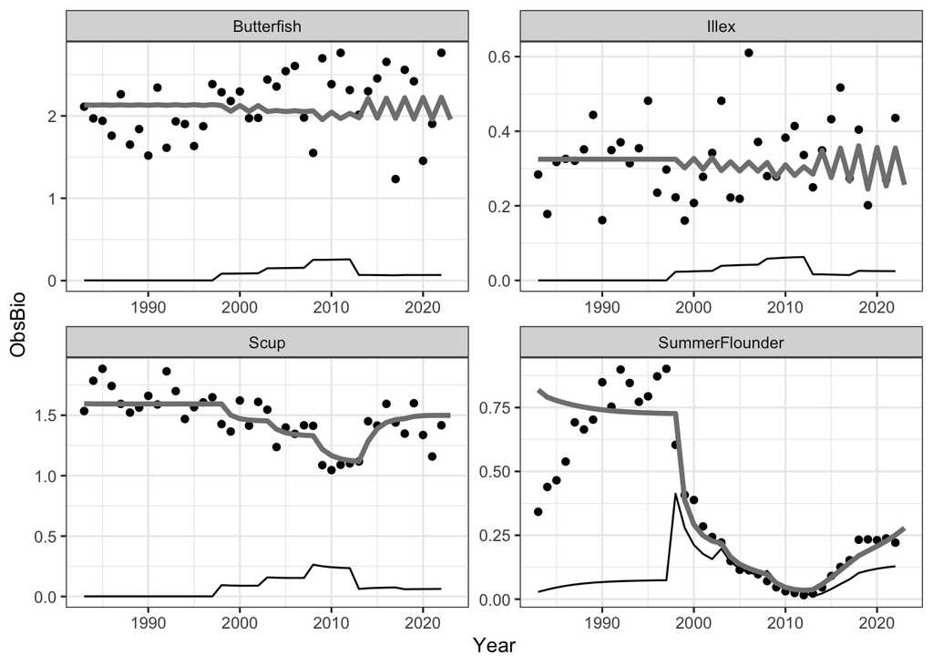

```r
#model may not be using the last data year? misaligned. a hack here to fix

fit.sf <- data.frame(value= MABsf$biomass,
                      Year=c(1983:2023),
                      Species="SummerFlounder")

fit.scup <- data.frame(value= MABscup$biomass,
                       Year=c(1983:2023),
                       Species="Scup")

fit.butter <- data.frame(value= MABbutter$biomass,
                       Year=c(1983:2023),
                       Species="Butterfish")

fit.illex <- data.frame(value= MABillex$biomass,
                       Year=c(1983:2023),
                       Species="Illex")


fits <- bind_rows(fit.sf, fit.scup, fit.butter, fit.illex)


MAB.data %>%
  ggplot()+
  geom_point(aes(x=Year, y=ObsBio)) +
  geom_line(aes(x=Year, y=TotCatch)) +
  geom_line(data=fits, aes(x=Year, y=value), lwd=1.3, col=gray(0.5)) +
  theme_bw() +
  facet_wrap(~Species, scales = "free")
```

Single species reference points for HCRs Pars from SS models above

```r
pars.sf <- data.frame(value= MABsf$pars,
                       Par=c("logK", "logr", "logsigma"),
                       Species="SummerFlounder")

pars.scup <- data.frame(value= MABscup$pars,
                           Par=c("logK", "logr", "logsigma"),
                           Species="Scup")

pars.butter <- data.frame(value= MABbutter$pars,
                           Par=c("logK", "logr", "logsigma"),
                           Species="Butterfish")

pars.illex <- data.frame(value= MABillex$pars,
                           Par=c("logK", "logr", "logsigma"),
                           Species="Illex")

pars <- bind_rows(pars.sf, pars.scup, pars.butter, pars.illex) %>%
  mutate(exppar = exp(value))
```

Reference points from single species models above for each species.

These are going into Rpath so ok to leave on this scale.

```r
SS.BMSY <- pars %>%
  filter(Par=="logK") %>%
  mutate(BMSY=exppar/2) %>%
  select(Species, BMSY)

SS.Fmsy <- pars %>%
  filter(Par == 'logr') %>%
  mutate(Fmsy= exppar/2) %>%
  select(Species, Fmsy)

saveRDS(SS.BMSY, file = here('MSE', 'BMSY.rds'))
saveRDS(SS.Fmsy, file = here('MSE', 'Fmsy.rds'))
```

# Set-up Rsim simulation and the closed loop

## Harvest control rules

### Mid-Atlantic HCR: Council Risk Policy and ABC Control Rule

The Mid-Atlantic ABC control rule is based on the MAFMC risk policy for probability of overfishing, pstar, combined with the uncertainty in the OFL, OFL CV. It was updated in 2020 to include higher risk tolerance at high stock size.

```r
riskpol <- data.frame(Bfrac = c(0, 0.1, 1.0, 1.5, 2.5),
                      Current = c(0, 0, 0.45, 0.49, 0.49),
                      Pre2020 = c(0, 0, 0.4, 0.4, 0.4)
)

riskpol <- riskpol %>%
  pivot_longer(-Bfrac, names_to = "pstar")

p1 <- ggplot2::ggplot(riskpol, aes(x=Bfrac, y=value, linetype = pstar)) +
  geom_path(show.legend = TRUE) +
  theme_minimal() +
  xlab("B/Bmsy") +
  ylab("p*") +
  labs(linetype = "Policy")+
  theme(legend.position="bottom")


#print(p1, vp=grid::viewport(gp=grid::gpar(cex=1.5)))
```

```r
ABCprop <- data.frame(Bfrac = seq(0, 2.5, 0.01)) %>%
  dplyr::mutate(pstar = case_when(Bfrac <= 0.1 ~ 0,
                                  Bfrac > 0.1 & Bfrac <= 1.0 ~ (Bfrac-0.1)*((0.45-0)/(1-0.1)) ,
                                  Bfrac > 1.0 & Bfrac <= 1.5 ~ (Bfrac-1.0)*((0.49-0.45)/(1.5-1))+0.45,
                                  Bfrac > 1.5 ~ 0.49)) %>%
  dplyr::mutate("CV=60%" = qlnorm(pstar, log(1), log(0.60 + 1)),
                "CV=100%" = qlnorm(pstar, log(1), log(1.00 + 1)),
                "CV=150%" = qlnorm(pstar, log(1), log(1.50 + 1))) %>%
  pivot_longer(-c(Bfrac, pstar), names_to = "CVlevel")


p2 <- ggplot2::ggplot(ABCprop, aes(x=Bfrac, y=value, colour=CVlevel)) +
  geom_line()+
  theme_minimal() +
  xlab("B/Bmsy") +
  ylab("ABC/OFL proportion") +
  labs(colour = "OFL CV") +
  theme(legend.position="bottom")

#print(p2, vp=grid::viewport(gp=grid::gpar(cex=1.5)))
```

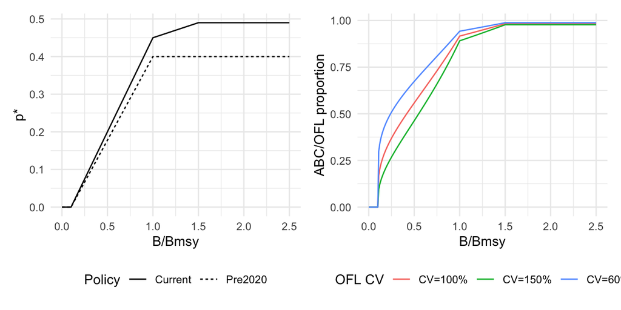

```r
p1 + p2
```

See [2020 MAFMC risk policy](https://www.mafmc.org/s/b_Implications-of-MAFMC-Risk-Policy-for-Multi.pdf) and [MAFMC ABC control rule](http://www.mafmc.org/s/MAFMC-ABC-Control-Rule-White-Paper.pdf)

The control rule adjusts OFL (Fofl = Fmsy * current B) to ABC using the risk policy’s pstar at current B as the percentile of OFL assuming that the OFL is lognormally distributed with CV = OFL CV.

Translating this into a control rule for Rpath requires some assumptions about OFL CV for each species. We can use the current OFL CVs as a starting point: * Summer flounder OFL CV 60% * Scup OFL CV 100% * Butterfish OFL CV 150% * Illex does not have full assessment or an OFL CV but if it did it might be 150%

```r
SS.OFLCV <- data.frame(Species = c("SummerFlounder", "Scup", "Butterfish", "Illex"),
                       OFLCV = c(0.60, 1.00, 1.50, 1.50))

control.pars <- list()

control.pars$Species <- SS.Fmsy$Species # FOFL

control.pars$Fofl <- SS.Fmsy$Fmsy

control.pars$OFLCV <- SS.OFLCV$OFLCV # FOFL

control.pars$pstar1 <- 0.49
control.pars$pstar2 <- 0.45
control.pars$pstar3 <- 0.0

# control.pars$H1 <- 0.75*SS.Fmsy$Fmsy #for alternative scenarios
# control.pars$H2 <- 0.5*SS.Fmsy$Fmsy
# control.pars$H3 <- 0.1*SS.Fmsy$Fmsy

control.pars$B1 <- 1.5*SS.BMSY$BMSY
control.pars$B2 <- 1.0*SS.BMSY$BMSY
control.pars$B3 <- 0.1*SS.BMSY$BMSY

control.pars$B4 <- 0.5*SS.BMSY$BMSY # not used in HCR but in status determination


#MAFMC ABC HCR
# This returns the ABC proportion of OFL rather than adjust the exploitation rate
# The calc in the MSE loop below is the returned harv*index so calc the ABC scalar here and apply it with Fofl in the loop
# Then we have Fofl*index = OFL * ABC scalar = ABC

  control <- function(estimated.biomass, control.pars, Species) {

    pstar1 <- control.pars$pstar1
    pstar2 <- control.pars$pstar2
    pstar3 <- control.pars$pstar3

    Fofl <- control.pars$Fofl[control.pars$Species==Species] #not needed here

    OFLCV <- control.pars$OFLCV[control.pars$Species==Species]

    B4 <- control.pars$B4[control.pars$Species==Species]

    B3 <- control.pars$B3[control.pars$Species==Species]
    B2 <- control.pars$B2[control.pars$Species==Species]
    B1 <- control.pars$B1[control.pars$Species==Species]

    H1 <- qlnorm(pstar1, log(1), log(OFLCV + 1))
    H2 <- qlnorm((estimated.biomass-B2)*((pstar1-pstar2)/(B1-B2))+pstar2, log(1), log(OFLCV + 1))
    H3 <- qlnorm((estimated.biomass-B3)*((pstar2-pstar3)/(B2-B3)), log(1), log(OFLCV + 1))
    H4 <- qlnorm(pstar3, log(1), log(OFLCV + 1))


    ABCscal <- ifelse(estimated.biomass >= B1, H1,
                   ifelse(estimated.biomass < B1 & estimated.biomass >= B2, H2,
                          ifelse(estimated.biomass < B2 & estimated.biomass >= B3, H3,
                                 ifelse(estimated.biomass < B3, H4, 0
                                 ))))
    return(ABCscal)
  }
```

HCR Shape: ABC (solid), OFL (dotted) for different levels of Rpath biomass, summer flounder black, scup red, butter green, illex blue

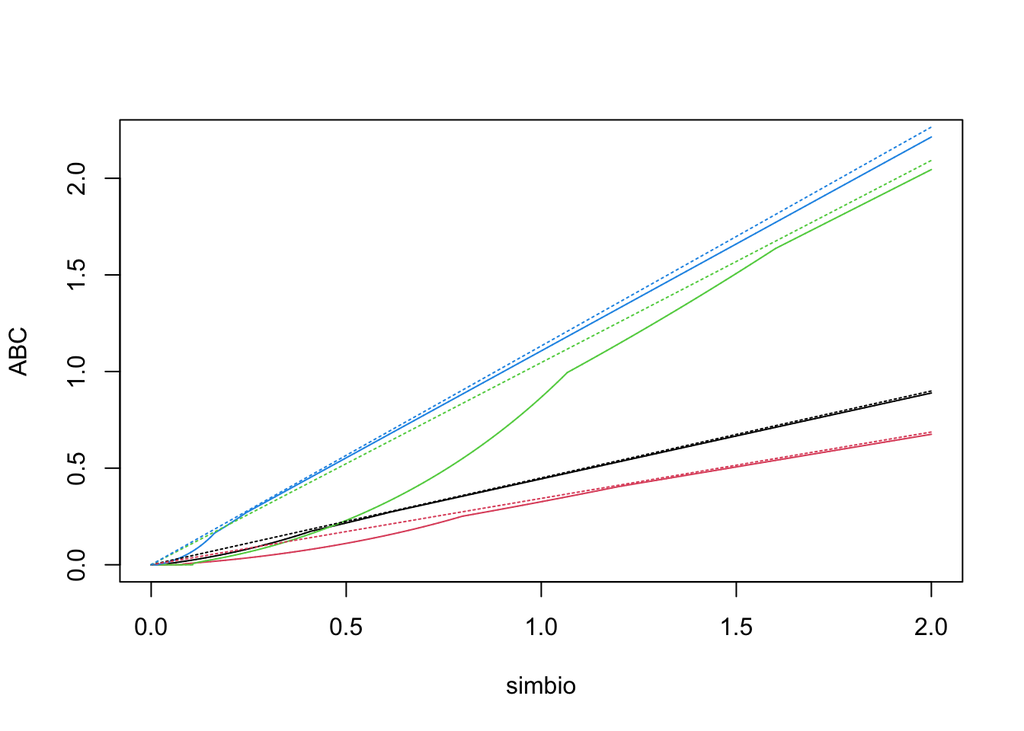

```r
simbio <- seq(0, 2.0, 0.0001)
sfABC <- control(simbio, control.pars, "SummerFlounder") * simbio * control.pars$Fofl[control.pars$Species=="SummerFlounder"]
scupABC <- control(simbio, control.pars, "Scup") * simbio * control.pars$Fofl[control.pars$Species=="Scup"]
butterABC <- control(simbio, control.pars, "Butterfish") * simbio * control.pars$Fofl[control.pars$Species=="Butterfish"]
illexABC <- control(simbio, control.pars, "Illex") * simbio * control.pars$Fofl[control.pars$Species=="Illex"]

maxy <- unique(max(illexABC, butterABC))

plot(simbio, sfABC, xlim=c(0,2), ylim = c(0, maxy), type = "n", ylab = "ABC")
lines(simbio, sfABC, col=1)
lines(simbio, scupABC, col=2)
lines(simbio, butterABC, col=3)
lines(simbio, illexABC, col=4)
lines(simbio, simbio * control.pars$Fofl[control.pars$Species=="SummerFlounder"], lty=3, col=1)
lines(simbio, simbio * control.pars$Fofl[control.pars$Species=="Scup"], lty=3, col=2)
lines(simbio, simbio * control.pars$Fofl[control.pars$Species=="Butterfish"], lty=3, col=3)
lines(simbio, simbio * control.pars$Fofl[control.pars$Species=="Illex"], lty=3, col=4)
```

We assume perfect implementation of the strategy - in that the realized catch is the same as the TAC. Will also have to convert the catch target to effort as that is what drives the Rsim dynamics. Rpath standardizes Effort to 1 so $Catch = qEB$ simplifies to $C = qB$ so $q = C/B$ or the initial $F$.

```r
#Cheating a little bit here
frates <- Rpath::frate.table(MAB.scene)
qtable <- frates[Group %in% c('SummerFlounder', 'Butterfish', 'Scup', "Illex"), list(Group, `Fixed Gear`, `LG Mesh`,  `SM Mesh`, Recreational)]

implement <- function(TAC, q, B, ...) {
effort <- TAC / (q * B)
return(effort)
}
```

## Projection

Will project forward for 20 years

CHANGE NOINTEGRATE IF NEEDED

```r
#Create initial scenario
MAB.scene <- rsim.scenario(MAB, MAB.rpath.params, years = 1983:2042)

#Apply the same initial fishing conditions
MAB.scene <- adjust.fishing(MAB.scene, parameter = 'ForcedEffort', group = 'LG Mesh',
                            sim.year = 1983:2017, value = c(rep(0, 15), rep(2.5, 5),
                                                            rep(5, 5), rep(10, 5),
                                                            rep(2.5, 5)))
MAB.scene <- adjust.fishing(MAB.scene, parameter = 'ForcedEffort', group = 'Fixed Gear',
                           sim.year = 1983:2017, value = c(rep(0, 15), rep(2.5, 5),
                                                           rep(5, 5), rep(10, 5),
                                                           rep(2.5, 5)))
MAB.scene <- adjust.fishing(MAB.scene, parameter = 'ForcedEffort', group = 'SM Mesh',
                            sim.year = 1983:2017, value = c(rep(0, 15), rep(1, 5),
                                                            rep(1.5, 5), rep(2, 5),
                                                            rep(0.5, 5)))
MAB.scene <- adjust.fishing(MAB.scene, parameter = 'ForcedEffort', group = 'Recreational',
                            sim.year = 1983:2017, value = c(rep(0, 15), rep(1, 5),
                                                            rep(1.5, 5), rep(2, 5),
                                                            rep(0.5, 5)))

#Hopefully fixes the instability in the model
MAB.scene$params$NoIntegrate[which(names(MAB.scene$params$NoIntegrate) %in%
                                    c('Micronekton', 'GelZooplankton', 'Krill'))] <- 0
# det.node <- which(names(MAB.scene$start_state$Biomass) == 'Detritus')
# pp.node  <- which(names(MAB.scene$start_state$Biomass) == 'Phytoplankton')
# MAB.scene <- adjust.forcing(MAB.scene, 'ForcedBio', group = 'Detritus',
#                            sim.year = 1983:2042,
#                            value = MAB.scene$start_state$Biomass[det.node])
# MAB.scene <- adjust.forcing(MAB.scene, 'ForcedBio', group = 'Phytoplankton',
#                            sim.year = 1983:2042,
#                            value = MAB.scene$start_state$Biomass[pp.node])

MAB.run <- rsim.run(MAB.scene, years = 1983:2022, method = 'AB')
```

## Run the closed loop

```r
set.seed(1234)

MAB.full <- copy(MAB.run)

#Divide TAC proportionally between the four gears
props <- qtable[, .SD / rowSums(.SD), .SDcols = c('LG Mesh', 'Fixed Gear',
                                                  'SM Mesh', 'Recreational')]
props[, Group := qtable[, Group]]

for(iyear in 2023:2042){
  MAB.full <- rsim.step(MAB.scene, MAB.full, method = 'AB', iyear)

  #New observations
  new.sf <- GenData(MAB.full, 'SummerFlounder', iyear, Sigma = 0.1)
  new.butter <- GenData(MAB.full, 'Butterfish', iyear, Sigma = 0.2)
  new.scup <- GenData(MAB.full, 'Scup', iyear, Sigma = 0.1)
  new.illex <- GenData(MAB.full, 'Illex', iyear, Sigma = 0.3)

  #New TAC
  index.sf <- new.sf$ObsBio
  index.butter <- new.butter$ObsBio
  index.scup <- new.scup$ObsBio
  index.illex <- new.illex$ObsBio

  #F_OFL is Fmsy
  Fofl.sf <- control.pars$Fofl[control.pars$Species=="SummerFlounder"]
  Fofl.butter <- control.pars$Fofl[control.pars$Species=="Butterfish"]
  Fofl.scup <- control.pars$Fofl[control.pars$Species=="Scup"]
  Fofl.illex <- control.pars$Fofl[control.pars$Species=="Illex"]

  TAC.sf <- control(index.sf, control.pars, Species = "SummerFlounder") * (index.sf * Fofl.sf)
  TAC.butter <- control(index.butter, control.pars, Species = "Butterfish") * (index.butter * Fofl.butter)
  TAC.scup <- control(index.scup, control.pars, Species = "Scup") * (index.scup * Fofl.scup)
  TAC.illex <- control(index.illex, control.pars, Species = "Illex") * (index.illex * Fofl.illex)


  #proportion TAC
  TAC.sf.lgm <- TAC.sf * props[Group == 'SummerFlounder', `LG Mesh`]
  TAC.sf.fix <- TAC.sf * props[Group == 'SummerFlounder', `Fixed Gear`]
  TAC.sf.smm <- TAC.sf * props[Group == 'SummerFlounder', `SM Mesh`]
  TAC.sf.rec <- TAC.sf * props[Group == 'SummerFlounder', `Recreational`]

  TAC.butter.lgm <- TAC.butter * props[Group == 'Butterfish', `LG Mesh`]
  TAC.butter.fix <- TAC.butter * props[Group == 'Butterfish', `Fixed Gear`]
  TAC.butter.smm <- TAC.butter * props[Group == 'Butterfish', `SM Mesh`]
  TAC.butter.rec <- TAC.butter * props[Group == 'Butterfish', `Recreational`]

  TAC.scup.lgm <- TAC.scup * props[Group == 'Scup', `LG Mesh`]
  TAC.scup.fix <- TAC.scup * props[Group == 'Scup', `Fixed Gear`]
  TAC.scup.smm <- TAC.scup * props[Group == 'Scup', `SM Mesh`]
  TAC.scup.rec <- TAC.scup * props[Group == 'Scup', `Recreational`]

  TAC.illex.lgm <- TAC.illex * props[Group == 'Illex', `LG Mesh`]
  TAC.illex.fix <- TAC.illex * props[Group == 'Illex', `Fixed Gear`]
  TAC.illex.smm <- TAC.illex * props[Group == 'Illex', `SM Mesh`]
  TAC.illex.rec <- TAC.illex * props[Group == 'Illex', `Recreational`]


  #Implement new TAC via effort
  #Recreational will be set by the lower effort between sf and scup, sm mesh sf and butterfish
  effort.smm <- min(c(implement(TAC.sf.smm, qtable[Group == 'SummerFlounder', `SM Mesh`],
                                index.sf),
                      implement(TAC.scup.smm, qtable[Group == 'Butterfish', `SM Mesh`],
                                index.scup)))
  effort.rec <- min(c(implement(TAC.sf.rec, qtable[Group == 'SummerFlounder', `Recreational`],
                                index.sf),
                      implement(TAC.scup.rec, qtable[Group == 'Scup', `Recreational`],
                                index.scup)))
  #LG Mesh set by summer flounder
  effort.lgm <- implement(TAC.butter.lgm, qtable[Group == 'SummerFlounder', `LG Mesh`],
                          index.butter)

  #Fixed set by scup
  effort.fix <- implement(TAC.scup.fix, qtable[Group == 'Scup', `Fixed Gear`],
                          index.scup)


  #Set new Effort
  MAB.scene <- adjust.fishing(MAB.scene, 'ForcedEffort', 'LG Mesh',
                             sim.year = iyear + 1, value = effort.lgm)
  MAB.scene <- adjust.fishing(MAB.scene, 'ForcedEffort', 'Fixed Gear',
                             sim.year = iyear + 1, value = effort.fix)
  MAB.scene <- adjust.fishing(MAB.scene, 'ForcedEffort', 'Recreational',
                             sim.year = iyear + 1, value = effort.rec)
  MAB.scene <- adjust.fishing(MAB.scene, 'ForcedEffort', 'SM Mesh',
                             sim.year = iyear + 1, value = effort.smm)

  }
```

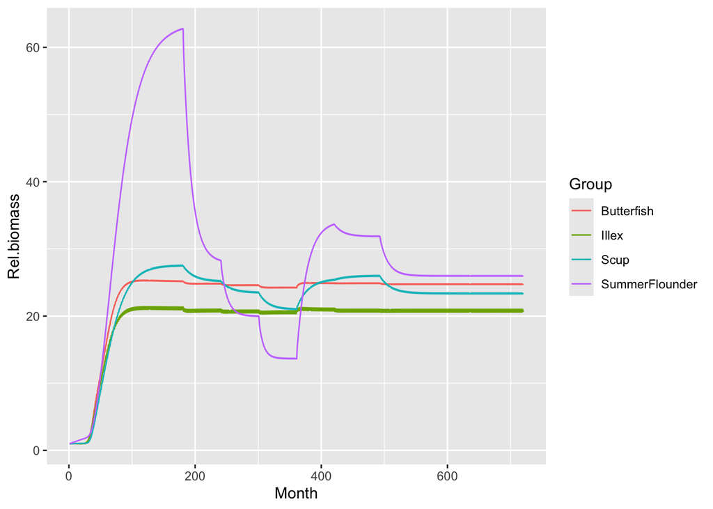

```r
#Plot results
MAB.bio <- as.data.table(MAB.full$out_Biomass)
MAB.bio[, Month := 1:nrow(MAB.bio)]
MAB.bio <- data.table::melt(MAB.bio, id.vars = 'Month', variable.name = 'Group',
                           value.name = 'Biomass')
start <- data.table::as.data.table(MAB.full$start_state$Biomass)
start[, Group := names(MAB.full$start_state$Biomass)]

MAB.bio <- merge(MAB.bio, start, by = 'Group')
MAB.bio[, Rel.biomass := Biomass / V1]

ggplot(MAB.bio[Group %in% c('SummerFlounder', 'Butterfish', 'Scup', 'Illex')],
       aes(x = Month, y = Rel.biomass, col = Group)) +
  geom_line()
```

Collect the results for further analysis

```r
#Get in a similar format to SS models run in other rmds
sp.cols <- which(colnames(MAB.full$annual_Biomass) %in% c('SummerFlounder', 'Butterfish', 'Scup', 'Illex'))

#Biomass
biomass <- as.data.table(MAB.full$annual_Biomass[, sp.cols])
biomass[, Year := 1983:2042]
biomass <- data.table::melt(biomass, id.vars = 'Year', variable.name = 'Species')
biomass[, type := 'biomass']

#Catch
catch <- as.data.table(MAB.full$annual_Catch[, sp.cols])
catch[, Year := 1983:2042]
catch <- data.table::melt(catch, id.vars = 'Year', variable.name = 'Species')
catch[, type := 'catch']

output <- rbindlist(list(biomass, catch))
output[, HCR := 'HCR_mineft']
```

## Rerun simulation but with max effort taken rather than min

```r
set.seed(123)

MAB.full <- copy(MAB.run)

#Divide TAC proportionally between the three gears
props <- qtable[, .SD / rowSums(.SD), .SDcols = c('LG Mesh', 'Fixed Gear',
                                                  'SM Mesh', 'Recreational')]
props[, Group := qtable[, Group]]

for(iyear in 2023:2042){
  MAB.full <- rsim.step(MAB.scene, MAB.full, method = 'AB', iyear)

  #New observations
  new.sf <- GenData(MAB.full, 'SummerFlounder', iyear, Sigma = 0.1)
  new.butter <- GenData(MAB.full, 'Butterfish', iyear, Sigma = 0.2)
  new.scup <- GenData(MAB.full, 'Scup', iyear, Sigma = 0.1)
  new.illex <- GenData(MAB.full, 'Illex', iyear, Sigma = 0.3)

  #New TAC
  index.sf <- new.sf$ObsBio
  index.butter <- new.butter$ObsBio
  index.scup <- new.scup$ObsBio
  index.illex <- new.illex$ObsBio

  #F_OFL is Fmsy
  Fofl.sf <- control.pars$Fofl[control.pars$Species=="SummerFlounder"]
  Fofl.butter <- control.pars$Fofl[control.pars$Species=="Butterfish"]
  Fofl.scup <- control.pars$Fofl[control.pars$Species=="Scup"]
  Fofl.illex <- control.pars$Fofl[control.pars$Species=="Illex"]

  TAC.sf <- control(index.sf, control.pars, Species = "SummerFlounder") * (index.sf * Fofl.sf)
  TAC.butter <- control(index.butter, control.pars, Species = "Butterfish") * (index.butter * Fofl.butter)
  TAC.scup <- control(index.scup, control.pars, Species = "Scup") * (index.scup * Fofl.scup)
  TAC.illex <- control(index.illex, control.pars, Species = "Illex") * (index.illex * Fofl.illex)


  #proportion TAC
  TAC.sf.lgm <- TAC.sf * props[Group == 'SummerFlounder', `LG Mesh`]
  TAC.sf.fix <- TAC.sf * props[Group == 'SummerFlounder', `Fixed Gear`]
  TAC.sf.smm <- TAC.sf * props[Group == 'SummerFlounder', `SM Mesh`]
  TAC.sf.rec <- TAC.sf * props[Group == 'SummerFlounder', `Recreational`]

  TAC.butter.lgm <- TAC.butter * props[Group == 'Butterfish', `LG Mesh`]
  TAC.butter.fix <- TAC.butter * props[Group == 'Butterfish', `Fixed Gear`]
  TAC.butter.smm <- TAC.butter * props[Group == 'Butterfish', `SM Mesh`]
  TAC.butter.rec <- TAC.butter * props[Group == 'Butterfish', `Recreational`]

  TAC.scup.lgm <- TAC.scup * props[Group == 'Scup', `LG Mesh`]
  TAC.scup.fix <- TAC.scup * props[Group == 'Scup', `Fixed Gear`]
  TAC.scup.smm <- TAC.scup * props[Group == 'Scup', `SM Mesh`]
  TAC.scup.rec <- TAC.scup * props[Group == 'Scup', `Recreational`]

  TAC.illex.lgm <- TAC.illex * props[Group == 'Illex', `LG Mesh`]
  TAC.illex.fix <- TAC.illex * props[Group == 'Illex', `Fixed Gear`]
  TAC.illex.smm <- TAC.illex * props[Group == 'Illex', `SM Mesh`]
  TAC.illex.rec <- TAC.illex * props[Group == 'Illex', `Recreational`]


  #Implement new TAC via effort
  #Recreational will be set by the lower effort between sf and scup, sm mesh sf and butterfish
  effort.smm <- max(c(implement(TAC.sf.smm, qtable[Group == 'SummerFlounder', `SM Mesh`],
                                index.sf),
                      implement(TAC.scup.smm, qtable[Group == 'Butterfish', `SM Mesh`],
                                index.scup)))
  effort.rec <- max(c(implement(TAC.sf.rec, qtable[Group == 'SummerFlounder', `Recreational`],
                                index.sf),
                      implement(TAC.scup.rec, qtable[Group == 'Scup', `Recreational`],
                                index.scup)))
  #LG Mesh set by summer Flounder
  effort.lgm <- implement(TAC.butter.lgm, qtable[Group == 'SummerFlounder', `LG Mesh`],
                          index.butter)

  #Fixed set by scup
  effort.fix <- implement(TAC.scup.fix, qtable[Group == 'Scup', `Fixed Gear`],
                          index.scup)


  #Set new Effort
  MAB.scene <- adjust.fishing(MAB.scene, 'ForcedEffort', 'LG Mesh',
                             sim.year = iyear + 1, value = effort.lgm)
  MAB.scene <- adjust.fishing(MAB.scene, 'ForcedEffort', 'Fixed Gear',
                             sim.year = iyear + 1, value = effort.fix)
  MAB.scene <- adjust.fishing(MAB.scene, 'ForcedEffort', 'Recreational',
                             sim.year = iyear + 1, value = effort.rec)
  MAB.scene <- adjust.fishing(MAB.scene, 'ForcedEffort', 'SM Mesh',
                             sim.year = iyear + 1, value = effort.smm)

  }
```

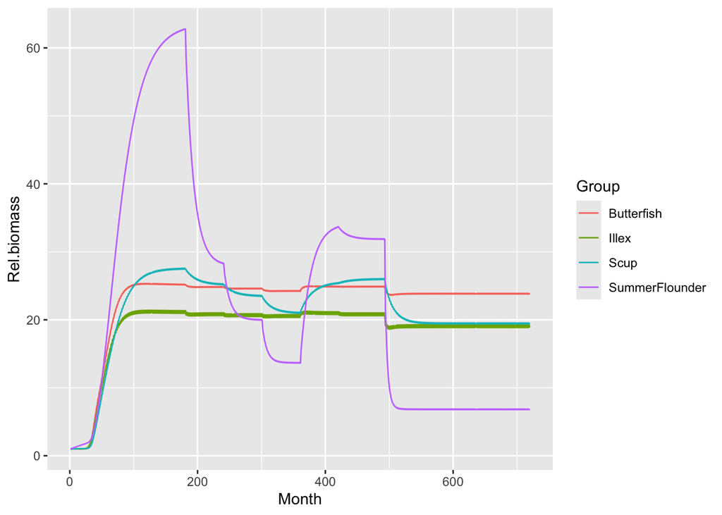

```r
#Plot results
MAB.bio <- as.data.table(MAB.full$out_Biomass)
MAB.bio[, Month := 1:nrow(MAB.bio)]
MAB.bio <- data.table::melt(MAB.bio, id.vars = 'Month', variable.name = 'Group',
                           value.name = 'Biomass')
start <- data.table::as.data.table(MAB.full$start_state$Biomass)
start[, Group := names(MAB.full$start_state$Biomass)]

MAB.bio <- merge(MAB.bio, start, by = 'Group')
MAB.bio[, Rel.biomass := Biomass / V1]

ggplot(MAB.bio[Group %in% c('SummerFlounder', 'Butterfish', 'Scup', "Illex")],
       aes(x = Month, y = Rel.biomass, col = Group)) +
  geom_line()
```

Collect the results for further analysis

```r
#Get in a similar format to SS models run in other rmds
sp.cols <- which(colnames(MAB.full$annual_Biomass) %in% c('SummerFlounder', 'Butterfish', 'Scup', 'Illex'))

#Biomass
biomass <- as.data.table(MAB.full$annual_Biomass[, sp.cols])
biomass[, Year := 1983:2042]
biomass <- data.table::melt(biomass, id.vars = 'Year', variable.name = 'Species')
biomass[, type := 'biomass']

#Catch
catch <- as.data.table(MAB.full$annual_Catch[, sp.cols])
catch[, Year := 1983:2042]
catch <- data.table::melt(catch, id.vars = 'Year', variable.name = 'Species')
catch[, type := 'catch']

output2 <- rbindlist(list(biomass, catch))
output2[, HCR := 'HCR_maxeft']

output <- rbindlist(list(output, output2))

saveRDS(output, file = here('MSE', 'MS_MAFMC_HCR.rds'))
```